# ggplot - Introduction

# 4 exercises

1. הרץ את הפקודה `ggplot(data = mpg)` מה אתה רואה?
2. צור scatter plot של של `class` ו-`drv`. מדוע הגרף לא מועיל?
3. מה לא בסדר בגרף הבא, מדוע הנקודות לא בצבע כחול?

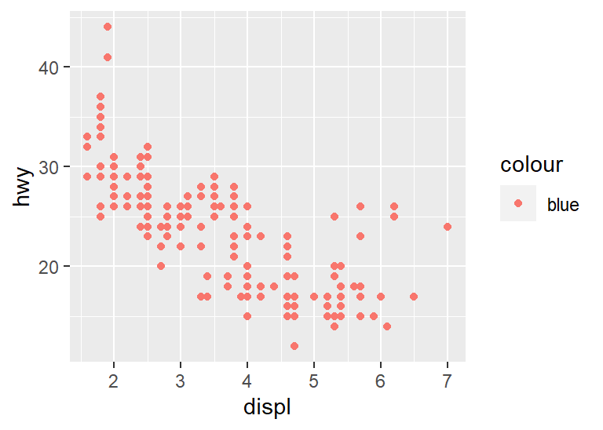

```r
ggplot(data = mpg) +
  geom_point(mapping = aes(x = displ, y = hwy, color = "blue"))
```

4. הקצה משתנה רציף לארגומנטים של ה - `color,size, shape`. איך ה aesthetics האלה מתנהגים שונה בין משתנים רציפים לבין משתנים קטגוריים?
5. מה קורה אם מקצים את אותו משתנה למספר aesthetics?
6. מה קורה אם מקצים aesthetic למשהו אחר משם משתנה כגון:

`aes(colour = displ < 5)`

7. מה קורה אם מקצים משתנה רציף ל-`facet`?
8. מה המשמעות של תאים ריקים בתרשים עם `facet_grid`(drv ~ cyl)`? איך הם מתקשים לתרשים הבא?

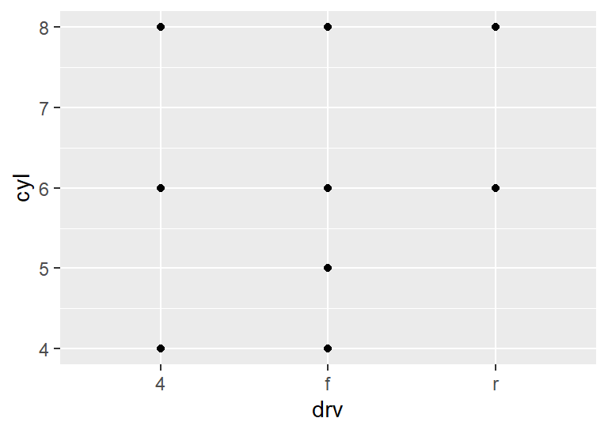

```r
ggplot(data = mpg) +
  geom_point(mapping = aes(x = drv, y = cyl))
```

9. קרא את `?facet_wrap`, מה הארגומנטים `ncol`, `nrow` עושים. אילו אפשרויות נוספות יש בכדי לאפיין את הפריסה של הגרף? למה ל-`facet_grid` אין את הארגומנטים `ncol`, `nrow` ?
10. הרץ את הקוד הבא בראשך ונסה לחזות מה הוא עושה. לאחר מכן, הרץ אותו ב-R ובדוק את התחזית שלך. מה התפקיד של הארגומנט `se = FALSE`)?

```r
ggplot(data = mpg, mapping = aes(x = displ, y = hwy, colour = drv)) +
  geom_point() +
  geom_smooth(se = FALSE)
```

11. האם שני הגרפים הבאים זהים? מדוע כן? מדוע לא?

```r
ggplot(data = mpg, mapping = aes(x = displ, y = hwy)) +
  geom_point() +
  geom_smooth()

ggplot() +
  geom_point(data = mpg, mapping = aes(x = displ, y = hwy)) +
  geom_smooth(data = mpg, mapping = aes(x = displ, y = hwy))
```

12. שחזר את הקוד שיוצר את הגרפים הבאים:

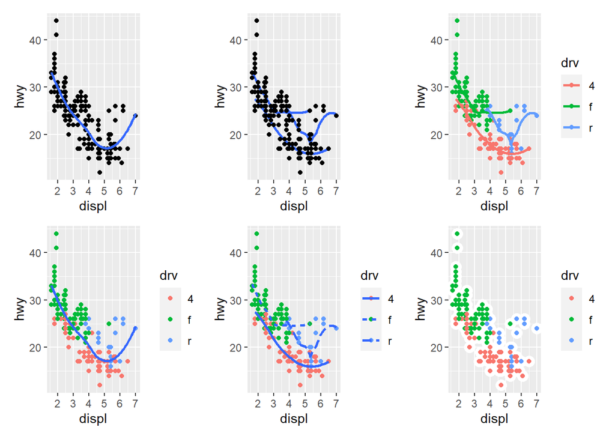

13. ייבא את נתוני Tara אשר השתמשנו בהם בשיעור הראשון, והרץ את הקוד הבא אשר יכין את הנתונים:

```r
tara <- readxl::read_xlsx(path = "../1 introduction/1_data/Tara.xlsx", sheet = "2010")

names(tara) <- c("date", "cat", "q_k", "revenue", "vc", "fc")

tara <- mutate(tara, gross_profit = revenue - vc - fc)

tara$date <- parse_date(tara$date, format = "%Y-%m-%d")

carton_milk <- tara %>% filter(str_detect(cat, pattern = "חלב קרטון")) %>%
  select(date,revenue, gross_profit)
```

הגרף הבא מציג את הרווח הגולמי והפדיון של חלב בקרטון. שחזר את הגרף תוך שימוש ב pivot_longer.

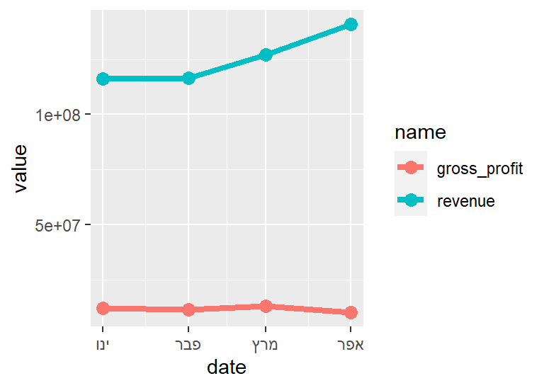

בנוסף, הקוד הבא מסנן את מעדני החלב:

```r
milk <- tara %>% filter(str_detect(cat, pattern = "חלב"))

milk <- milk %>% filter( !str_detect(cat, pattern = "מעדני"))

milk <- milk %>% select(date, revenue, gross_profit, cat)
```

הגרף הבא מציג את הרווח הגולמי והפדיון עבור משקאות חלב. שחזר את הגרף תוך שימוש ב- pivot_longer ושימוש ב-facet_wrap.

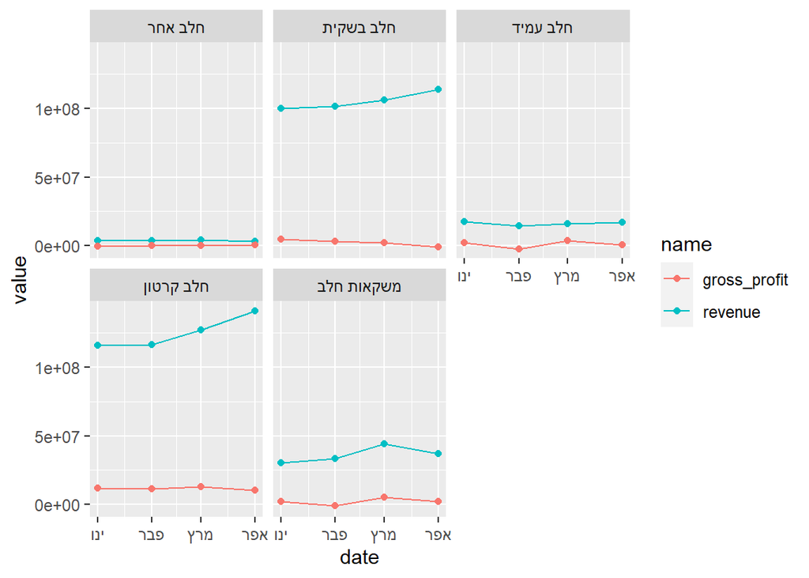

# 5 coordinate systemns

למערכות קואורדינטות יש שני תפקידים:  
1. שילוב שני aesthetics של מיקום לשני ממדים על הגרף.  
2. בשילוב עם ה-facet, לצייר צירים ורקע לגרף.

יש מערכות קואורדינטות ליניאריות כמו:  
`coord_cartesian` , ברירת המחדל של הגרפים בה המיקום של רכיב ניתן ע"י שילוב מיקומי קואורדינטות x ו-y.  
`coord_flip` אשר הופך את הצירים.  
`coord_fixed` אשר מקבע את מערכת הקואורדינטות ליחס מסוים בין הצירים.

מצד שני, יש מערכת קואורדינטות לא ליניאריות בהן קו ישר עשוי להיות לא ישר, והמרחק בין שתי נקודות לא חייב להיות בקו ישר.  
למשל, `coord_polar` משמשת ליצירת תרשימי עוגה.

## 5.1 coord_flip

`coord_flip` נח לשימוש כאשר התוויות על הציר האופקי ארוכות:

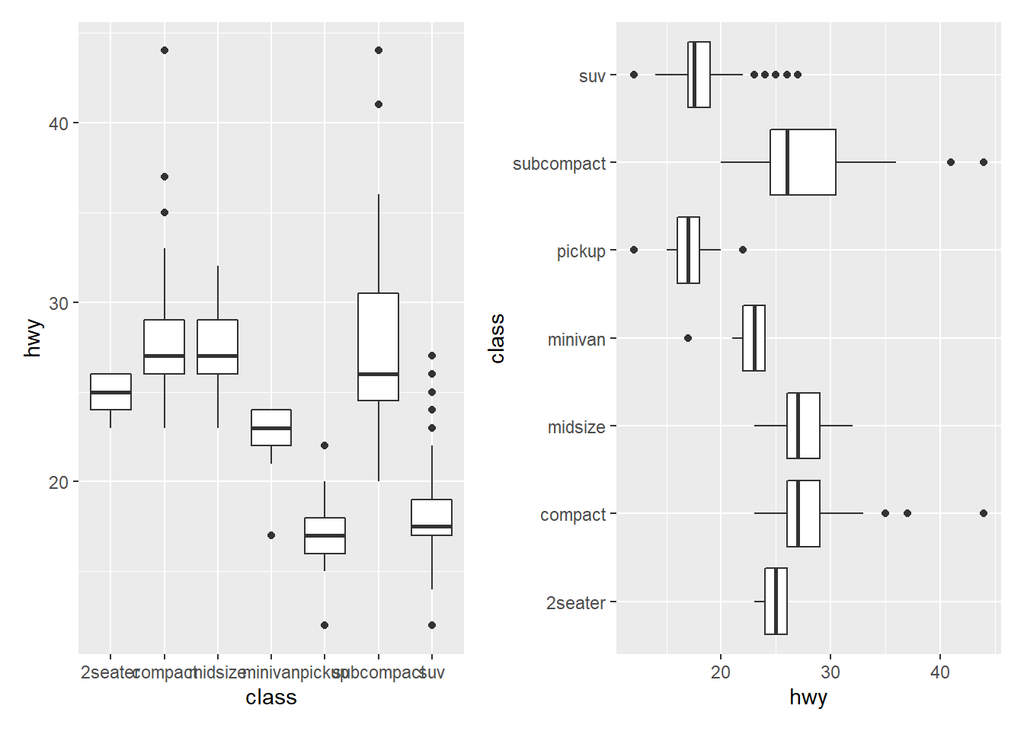

```r
p1 <- ggplot(data = mpg, mapping = aes(x = class, y = hwy)) +
  geom_boxplot()

p2 <- ggplot(data = mpg, mapping = aes(x = class, y = hwy)) +
  geom_boxplot() +
  coord_flip()

p1 + p2
```

## 5.2 coord cartesian

נשתמש ב-`coord_cartesian` כאשר נרצה לעשות zoom על הגרף.

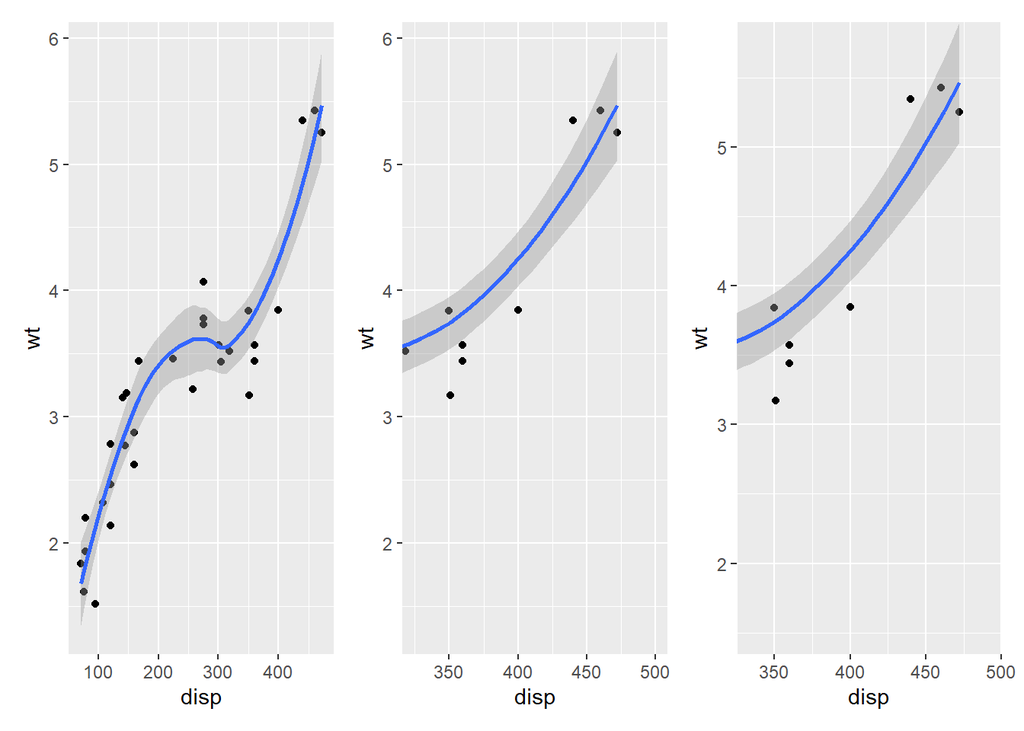

```r
p1 <- ggplot(mtcars, aes(disp, wt)) +
  geom_point() + geom_smooth()

p2 <- p1 + coord_cartesian(xlim = c(325, 500))

p3 <- p1 + coord_cartesian(xlim = c(325, 500), expand = FALSE)


p1 + p2 + p3
## `geom_smooth()` using method = 'loess' and formula 'y ~ x'
## `geom_smooth()` using method = 'loess' and formula 'y ~ x'
## `geom_smooth()` using method = 'loess' and formula 'y ~ x'
```

צריך להבדיל בין מצבו בו עושים zoom באמצעות מערכת הקואורדינטות לבין מצב בו משנים את גבולות הגרף באמצעות ה-scale. הגדרת גבולות באמצעות ה-scale הופך את כל הערכים מחוץ לתחום ל-NA.

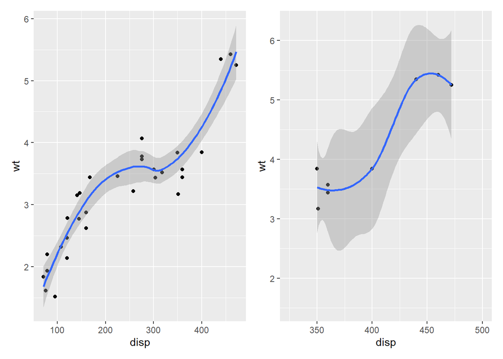

```r
p4 <- p1 + scale_x_continuous(limits = c(325, 500))

p1 + p4
## `geom_smooth()` using method = 'loess' and formula 'y ~ x'
## `geom_smooth()` using method = 'loess' and formula 'y ~ x'
## Warning: Removed 24 rows containing non-finite values (stat_smooth).
## Warning: Removed 24 rows containing missing values (geom_point).
```

דוגמא נוספת, בתרשימים הבאים נוסף קו אופקי ב- `y = 28`. התרשים השמאלי הוא המקורי. בתרשים האמצעי ביצעו zoom in, ובתרשים השמאלי שינינו את ההתפלגות באמצעות שימוש בפונקציית `ylim` הקובעת גבולות לפונקציית ה-`scale`. כל הערכים מחוץ לתחום (10, 35) הפכו ל-NA, ורק לאחר מכן הסטטיסטי חושב. התוצאה היא שהחציון מוטה כלפי מטה.

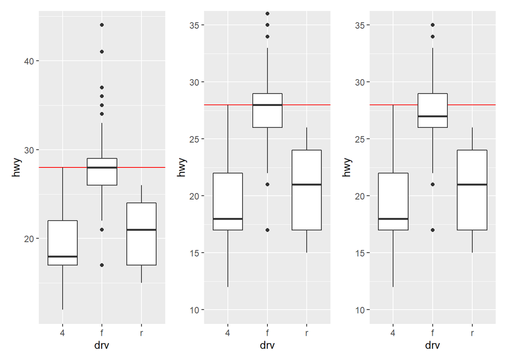

```r
p1 <- ggplot(mpg, aes(drv, hwy)) +
  geom_hline(yintercept = 28, colour = "red") +
  geom_boxplot()

p2 <- p1  + coord_cartesian(ylim = c(10, 35)) # zoom in

p3 <- p1 + ylim(10, 35) # alters the data

p1 | p2 | p3
```

# 6 themes

ה-`theme` מאפשר שליטה על רכיבים **שאינם data** ומאפשר לעצב את הגרף כך שיהיה נעים לעין. למשל, הוא מאפשר שליטה על פונטים, ticks ורקע.  
ה-`theme` מורכב מארבעה רכיבים עיקריים:  
`non data element`- נבחר אותו כשרוצים לשנות משהו כמו: `plot.title` או `axis.ticks.x`.  
`elment function` - המתארת את התכונות הויזואליות של הרכיב. למשל, `element_text` קובעת את גודל הפונט, הצבע, וסוג הפורט של `plot.title`.  
פונקציית ה-`theme` המאפשרת לשכתב את ברירת המחדל של הגרף. למשל:

`theme(plot.title = element_text(colour = "red"))`

יש גם `complete theme` כגון `theme_gray` או `IA_theme` הקובעת את כל הרכיבים של ה- theme לערכים שהותאמו זה לזה.  
דוגמא:

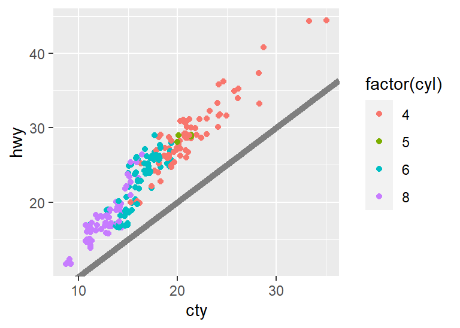

```r
base <- ggplot(mpg, aes(cty, hwy, color = factor(cyl))) +
  geom_jitter() +
  geom_abline(colour = "grey50", size = 2)

base
```

נוסיף כותרות, נשנה כותרות צירים ו-legend, ונשנה את פלטת הצבעים.

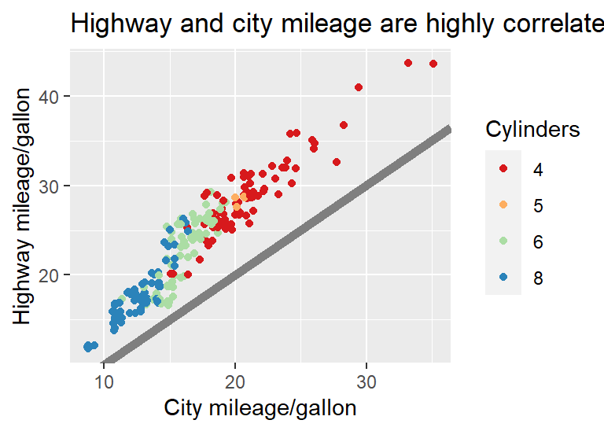

```r
labelled <- base +
  labs(
    x = "City mileage/gallon",
    y = "Highway mileage/gallon",
    colour = "Cylinders",
    title = "Highway and city mileage are highly correlated"
    ) +
  scale_colour_brewer(type = "seq", palette = "Spectral")

labelled
```

כעת נרצה לעצב את התרשים כך שיתאים לפורמט של ז’ורנל מסוים: נהפוך את הרגע ללבן, נמקם את ה legend בתוך הגרף, נשנה את קווי הגריד, ואת הפונט של הכותרת.

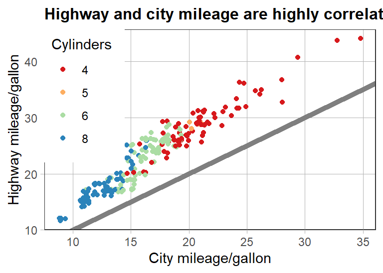

```r
styled <- labelled +
  theme_bw() +
  theme(
    plot.title = element_text(face = "bold", size = 12),
    legend.background = element_rect(fill = "white", size = 4, colour = "white"),
    legend.justification = c(0, 1),
    legend.position = c(0, 1),
    axis.ticks = element_line(colour = "grey70", size = 0.2),
    panel.grid.major = element_line(colour = "grey70", size = 0.2),
    panel.grid.minor = element_blank()
  )

styled
```

בכדי לשנות רכיב ב-`theme` משתמשים בקוד מהצורה:

`plot + theme(element.name = element.function())`

יש כ-40 element.names שונים. ביניהם: plot.background, plot.title, plot.margin באמצעותם ניתן לעצב את הרקע, הכותרת והשטחים מסביב לגריד בהתאמה.  
את ה element.function ניתן לחלק ל-4 סוגים עיקריים:

`element.text, element.rect, element.blank, element.line`.

הנה כמה דוגמאות:

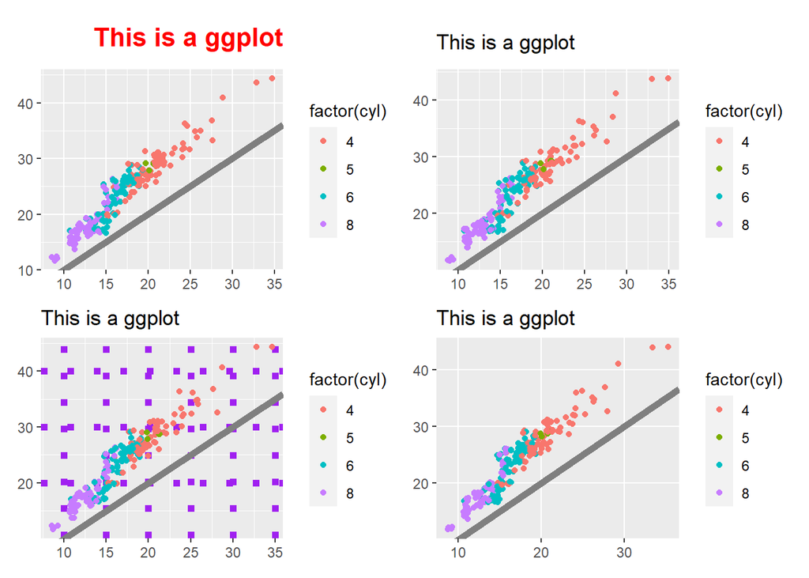

```r
base_t <- base + labs(title = "This is a ggplot") + xlab(NULL) + ylab(NULL)

p1 <- base_t + theme(plot.title = element_text(face = "bold", colour = "red", hjust = 1, size = 16))

p2 <- base_t + theme(plot.title = element_text(margin = margin(t = 10, b = 10)))

p3 <- base_t + theme(panel.grid.major = element_line(size = 2, linetype = "dotted", color = "purple"))

p4 <- base_t +  theme(panel.grid.minor = element_blank())

p1 + p2 + p3 + p4
```

יש themes שלמים שמגיעים עם ggplot, יש באינטרנט להורדה, ויש את ה-theme שכתבתי עבורנו ונמצא בחבילה `IA_plots`

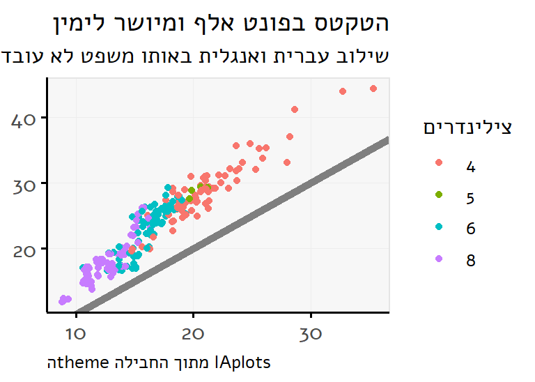

```r
library(IAplots)
base_t + IA_theme() +
  labs(title = "הטקטס בפונט אלף ומיושר לימין",
       subtitle = "שילוב עברית ואנגלית באותו משפט לא עובד טוב",
       color = "צילינדרים",
       caption = "הtheme מתוך החבילה IAplots")
```

ניתן לשנות את ה- `theme` ברירת מחדל בסשן באמצעות:

```r
theme_set("your theme name")
```

אפשר לשמור את התרשים בפורמטים ווקטורים או בפורמטים פיקסליים. ואת גודל התמונה שתישמר ניתן להגדיר באינצ’ים (ברירת המחדל) סנטימטרים או מילימטרים.  
`ggsave` תשמור את התרשים האחרון שהוצג או את התרשים ששמו הוזן בארגומנט ה-`plot` בפונקציה.

```r
ggsave(filename = "6_plots/test_plot.png", width = 10, height = 7)
```

ניתן גם לשמור תרשימים גם באמצעות לחצן ה-export בממשק ה-RStudio. אולם, שמירה באמצעות הקוד מבטיח שתוכלו למצוא לאחר מכן את הקשר בין גרף לבין הקוד שיצר אותו. למשל, ניתן להשתמש בתפריט edit -> find in files בכדי לחפש string מסוים בקבצי קוד.

more tricks

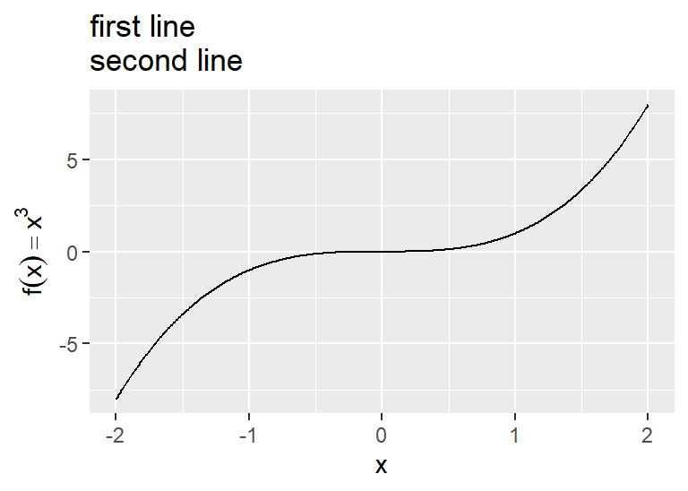

```r
values <- seq(from = -2, to = 2, by = .01)

df <- data.frame(x = values, y = values ^ 3)

ggplot(df, aes(x, y)) +
  geom_path() +
  labs(y = quote(f(x) == x^3),
       title = "first line \nsecond line")
```